# Exercise 4

# Exercise 4

loading libraries

```r
library("limma")
library("ggplot2")
```

*Setting parameters*

```r
nGenes <- 10000                   # number of "features"
nSamples <- 6                     # number of samples (split equal in 2 groups)
pDiff <- .1                       # percent of genes "differential
grp <- rep(0:1,each=nSamples/2)   # dummy variable for exp. group
trueFC <- 2                       # log-fold-change of truly DE

d0 <- 1                     # residual standard deviation pooled
s0 <- 0.8
sd <- s0*sqrt(d0/rchisq(nGenes,df=d0))  # dist'n of s.d.
```

Generating table of (null) data

```r
y <- matrix(rnorm(nGenes*nSamples,sd=sd),
            nr=nGenes,nc=nSamples)
```

We add in “differential expression”, randomly chosen to be in the positve or negative direction, to set of indices chosen:

```r
indD <- 1:floor(pDiff*nGenes)
diff <- sample(c(-1,1),max(indD),replace=TRUE)*trueFC
y[indD,grp==1] <- y[indD,grp==1] + diff
```

## Question 1

Exploratory analysis of the true and observed variances

residual variance for each row

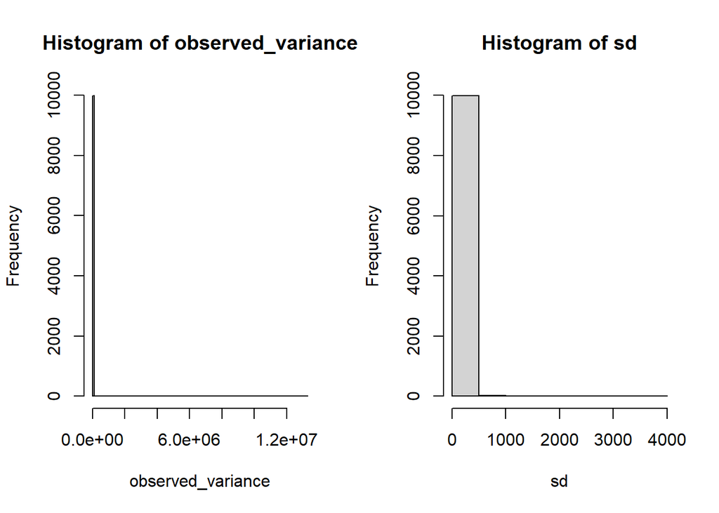

```r
n1=3
n2=3

observed_variance = c()
for (i in 1:10000){
 observed_variance[i] = ((n1-1)*var(y[i,1:3]) + (n2-1)*var(y[i,4:6]))/(n1+n2-2)
}
par(mfrow=c(1,2))
hist(observed_variance, breaks = 100)
hist(sd,breaks =10)
```

in log-scale

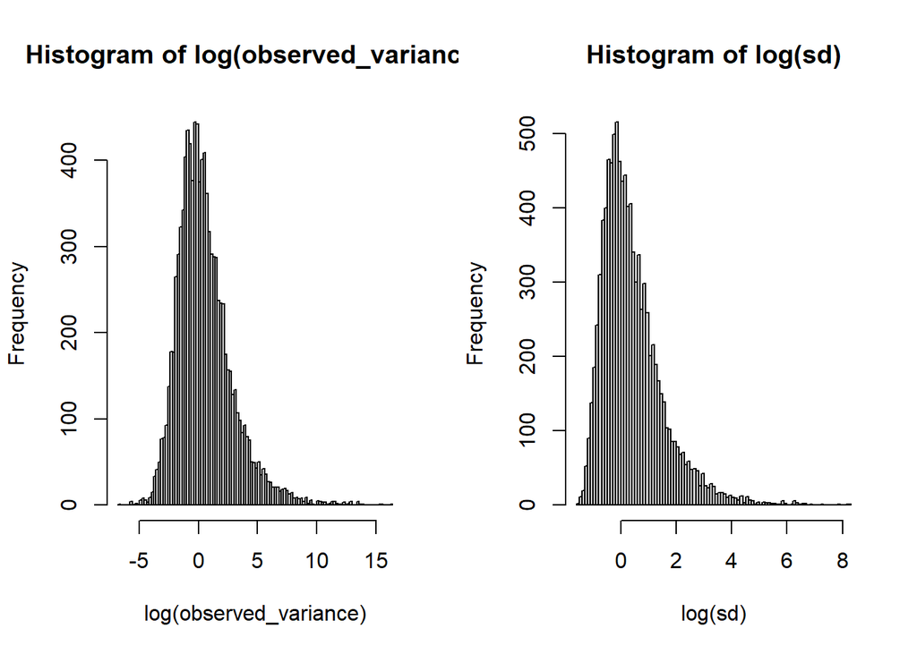

```r
par(mfrow=c(1,2))
hist(log(observed_variance), breaks = 100)
hist(log(sd),breaks =100)
```

scatter plot

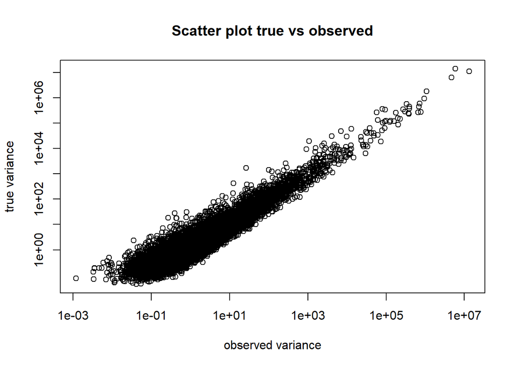

```r
plot(observed_variance,sd^2, main = "Scatter plot true vs observed", xlab= "observed variance", ylab= "true variance", log = "xy")
```

the observed nd the true variances dont vary that much

## Question 2

“differential expression” changes the mean of the feature (genes). the diff was “added” to the grp==1 columns of the first 1000 rows

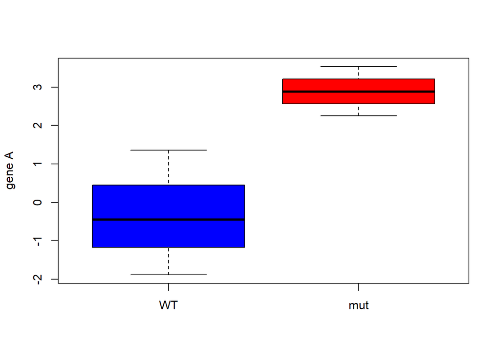

```r
gene_A_WT =y[which(diff==2)[1],1:3]
gene_A_mut =y[which(diff==2)[1],4:6]

boxplot(gene_A_WT, gene_A_mut, ylab= "gene A", col= c("blue", "red"), names = c("WT","mut"))
```

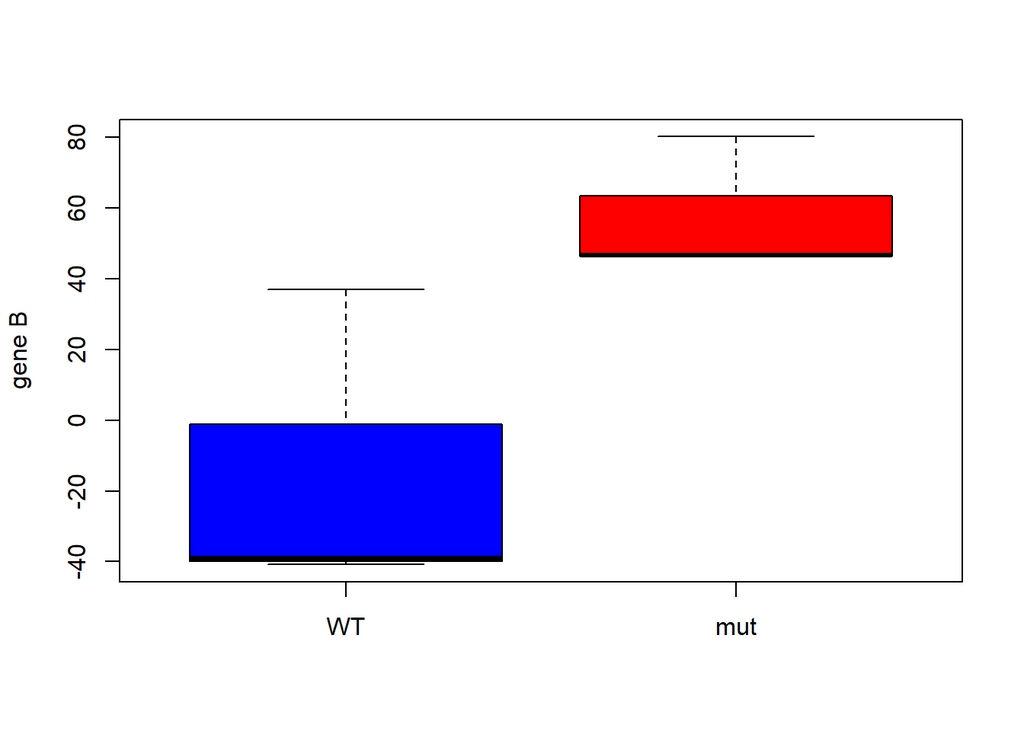

```r
gene_B_wt = y[which(diff==-2)[1],1:3]
gene_B_mut =y[which(diff==-2)[1],4:6]

boxplot(gene_B_wt,gene_B_mut, ylab= "gene B", col= c("blue", "red"), names = c("WT","mut"))
```

Next we create a design matrix to represent the linear model fit (to each row of the table) by limma

```r
(design = model.matrix(~grp))
```

```
  (Intercept) grp
1           1   0
2           1   0
3           1   0
4           1   1
5           1   1
6           1   1
attr(,"assign")
[1] 0 1
```

## Question 3

> in terms of the model that is fit for each feature, what is the interpretation of the two columns of this design matrix?

Linear model fit for each feature

```r
fit= lmFit(y,design)
fit = eBayes(fit)

names(fit)
```

```
 [1] "coefficients"     "rank"             "assign"           "qr"
 [5] "df.residual"      "sigma"            "cov.coefficients" "stdev.unscaled"
 [9] "pivot"            "Amean"            "method"           "design"
[13] "df.prior"         "s2.prior"         "var.prior"        "proportion"
[17] "s2.post"          "t"                "df.total"         "p.value"
[21] "lods"             "F"                "F.p.value"
```

The true differential “status”

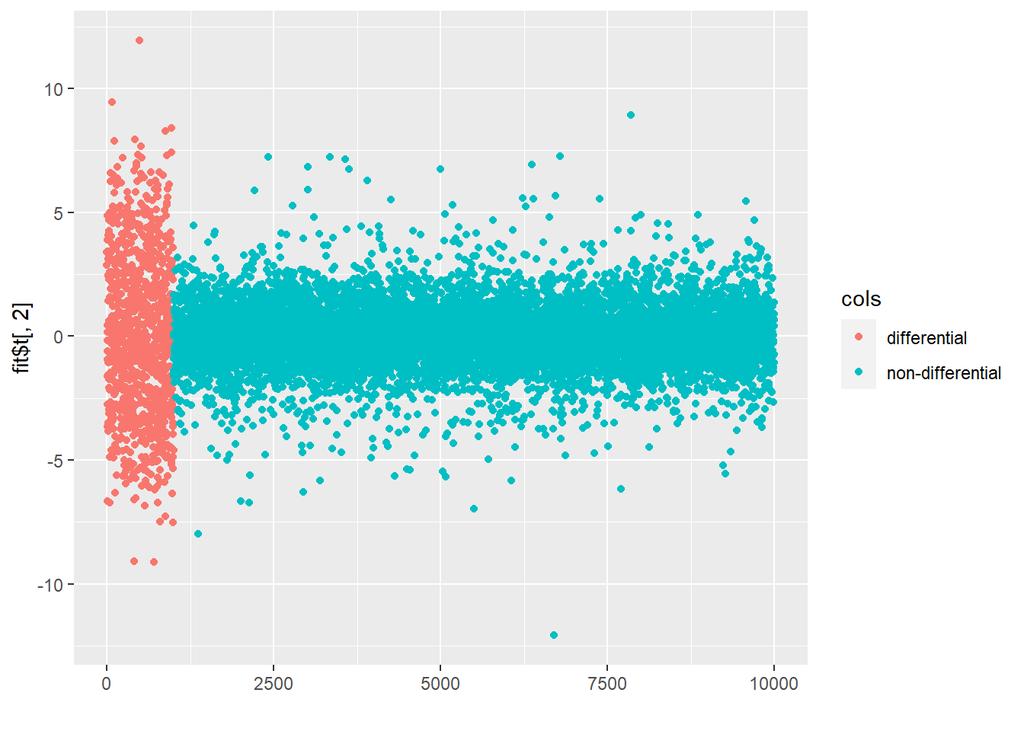

```r
cols = rep("non-differential", nrow(y))
cols[indD] = "differential"

qplot(y=fit$t[,2])+geom_point(aes(colour = cols))
```

the coefficients

```r
fit$coefficients
```

```
           (Intercept)           grp
    [1,] -3.297437e-01  3.219630e+00
    [2,] -1.430998e+01  7.201785e+01
    [3,] -3.198949e+00 -3.257110e+00
    [4,]  9.877085e-01  5.628963e+00
    [5,]  2.616006e+00  3.342414e+00
    [6,]  1.342312e+00  8.440275e-01
    [7,] -3.144457e-01 -2.003436e+00
    [8,]  2.148441e-01  1.960934e+00
    [9,]  4.700205e+00 -4.740327e+00
   [10,]  5.755235e-01  2.366969e+00
   [11,]  6.699271e-01 -3.011226e+00
   [12,]  4.200894e+00 -2.633528e+00
   [13,]  1.937006e+00 -3.377592e+00
   [14,] -3.963978e+00 -6.939234e-01
```

[output cut: 9986 more lines]

*answer to Question 3* The first column is the intercept and the 2nd column the slope. The intercept is parameterised for the mean expression of the first group (0) and the second column is parameterised for the mean expression of the 2nd group (1) relative to the first group (0). The slope tells us how much the gene expression of each genes changes from 1st and 2nd group.

##Question 4

Calculate for each row of y classical two sample t-test

T.Test with common variance

```r
t_values = c()
p_values = c()
for (i in 1:nrow(y)){
  t_values[i] = t.test(y[i,4:6],y[i,1:3], var.equal = T)$statistic
  p_values[i] = t.test(y[i,4:6],y[i,1:3], var.equal = T)$p.value
}
```

Add visualisation

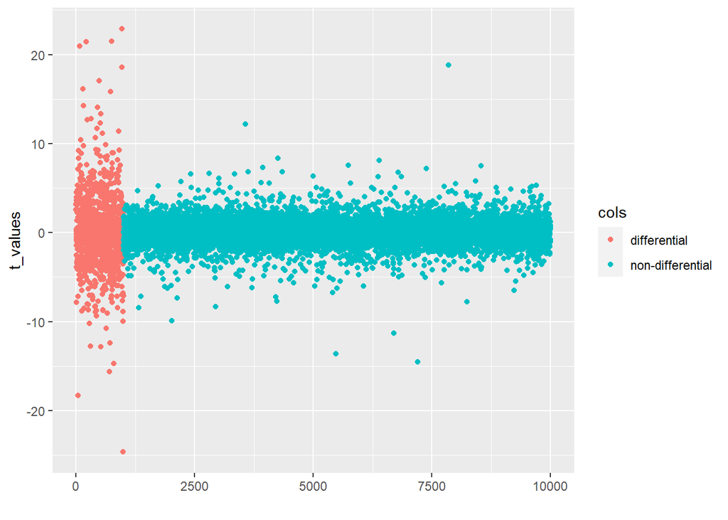

```r
cols = rep("non-differential", nrow(y))
cols[indD] = "differential"

qplot(y=t_values)+geom_point(aes(colour = cols))
```

*log-fold-change*

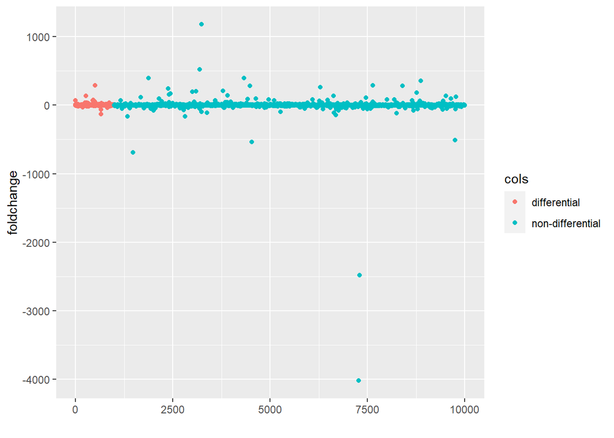

```r
#calculate the mean of each gene per control group
WT = apply(y[,1:3], 1, mean)

#calcuate the mean of each gene per test group
mut = apply(y[, 4:6], 1, mean)

#foldchange
foldchange = mut-WT

cols = rep("non-differential", nrow(y))
cols[indD] = "differential"

qplot(y=foldchange)+geom_point(aes(colour = cols))
```

The moderated t-test is seems to be better in separating the differential from non differential expressed genes. The fold change performs the worst in separating the truly differential from the non-differential.

## Question 5

*False discovery plot*

moderated t-test

```
Step 1... determine cutoff point
Step 2... estimate parameters of null distribution and eta0
Step 3... compute p-values and estimate empirical PDF/CDF
Step 4... compute q-values and local fdr
Step 5... prepare for plotting
```

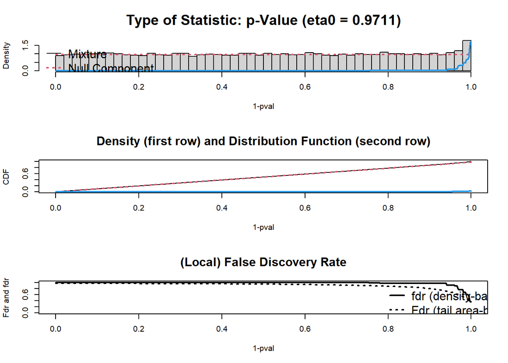

```r
library(fdrtool)

p.value = as.vector(fit$p.value)

windows(10,5) #to avoid getting the figure margins too large error
fdr = fdrtool(p.value, statistic = "pvalue")
```

for the two-sample t-test

```
Step 1... determine cutoff point
Step 2... estimate parameters of null distribution and eta0
Step 3... compute p-values and estimate empirical PDF/CDF
Step 4... compute q-values and local fdr
Step 5... prepare for plotting
```

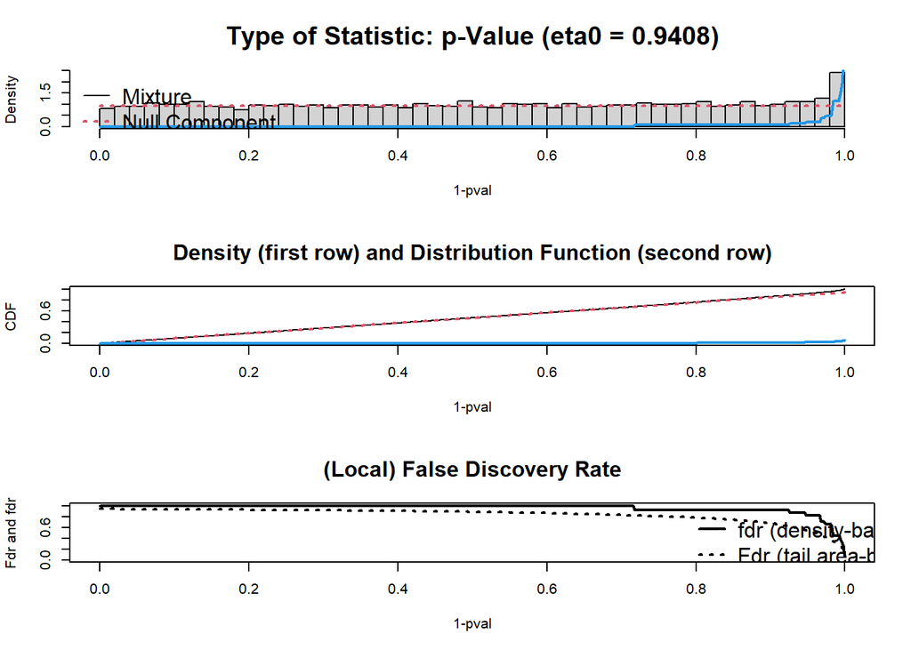

```r
windows(10,5) #to avoid getting the figure margins too large error
fdr = fdrtool(p_values, statistic = "pvalue")
```

log-Fold chnage

```r
true_foldchange = rep(0,nrow(y))
true_foldchange[indD] = diff


t.test(true_foldchange, foldchange)
```

```
    Welch Two Sample t-test

data:  true_foldchange and foldchange
t = 0.45001, df = 10002, p-value = 0.6527
alternative hypothesis: true difference in means is not equal to 0
95 percent confidence interval:
 -0.7815234  1.2472858
sample estimates:
 mean of x  mean of y
-0.0024000 -0.2352812
```

unzipping and loading the data

```r
library("affy")
library("preprocessCore")
unzip("affy_estrogen.zip")
ddir <- "affy_estrogen"
dir(ddir)
```

```
[1] "high10-1.cel" "high10-2.cel" "high48-1.cel" "high48-2.cel" "low10-1.cel"
[6] "low10-2.cel"  "low48-1.cel"  "low48-2.cel"  "targets.txt"
```

```r
# preprocess affymetrix data
targets <- readTargets("targets.txt", path=ddir)
targets$time.h <- factor(targets$time.h)
targets
```

```
      filename estrogen time.h
1  low10-1.cel   absent     10
2  low10-2.cel   absent     10
3 high10-1.cel  present     10
4 high10-2.cel  present     10
5  low48-1.cel   absent     48
6  low48-2.cel   absent     48
7 high48-1.cel  present     48
8 high48-2.cel  present     48
```

```r
abatch <- ReadAffy(filenames=targets$filename,
                   celfile.path=ddir)
eset <- rma(abatch)  # bg correct, normalize, summarize
```

```
Background correcting
Normalizing
Calculating Expression
```

summary of the dataset using *multidimensional scaling plot* >(the distance on the plot approximated the log2 fold changes)

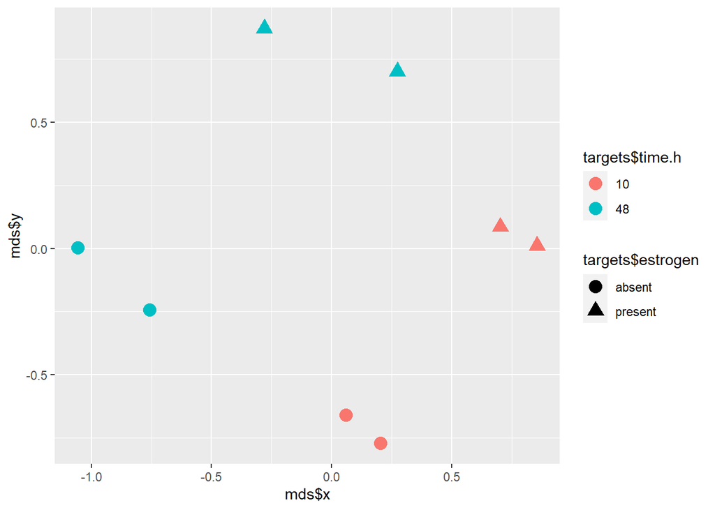

```r
mds <- plotMDS( exprs(eset), plot = FALSE)  # MDS plot
qplot(x=mds$x, mds$y) +
  geom_point(aes(shape=targets$estrogen,
                 colour=targets$time.h), size=4)
```

*creating the design matrix*

```r
# do the limma modeling
f <- paste(targets$estrogen,targets$time.h,sep="")
f <- factor(f)

# create design matrix
design <- model.matrix(~0+f)
colnames(design) <- levels(f)
design
```

```
  absent10 absent48 present10 present48
1        1        0         0         0
2        1        0         0         0
3        0        0         1         0
4        0        0         1         0
5        0        1         0         0
6        0        1         0         0
7        0        0         0         1
8        0        0         0         1
attr(,"assign")
[1] 1 1 1 1
attr(,"contrasts")
attr(,"contrasts")$f
[1] "contr.treatment"
```

*fitting the model*

```r
fit <- lmFit(eset, design)
```

*defining the conttast matrix*

```r
cont.matrix <- makeContrasts(E10="present10-absent10",
                             E48="present48-absent48",
                             Time="absent48-absent10",levels=design)
cont.matrix
```

```
           Contrasts
Levels      E10 E48 Time
  absent10   -1   0   -1
  absent48    0  -1    1
  present10   1   0    0
  present48   0   1    0
```

*fit the contrast to the model*

```r
fit2  <- contrasts.fit(fit, cont.matrix)
fit2  <- eBayes(fit2)
class(fit2)
```

```
[1] "MArrayLM"
attr(,"package")
[1] "limma"
```

```r
names(fit2)
```

```
 [1] "coefficients"     "rank"             "assign"           "qr"
 [5] "df.residual"      "sigma"            "cov.coefficients" "stdev.unscaled"
 [9] "pivot"            "Amean"            "method"           "design"
[13] "contrasts"        "df.prior"         "s2.prior"         "var.prior"
[17] "proportion"       "s2.post"          "t"                "df.total"
[21] "p.value"          "lods"             "F"                "F.p.value"
```

*summarize the differential expression statistic* > coef: specifying which coefficient or contrast of the linear model is of interest

coef=1 we are looking at present10-absent10

```r
topTable(fit2, coef=1, n=5)
```

```
            logFC   AveExpr        t      P.Value    adj.P.Val        B
39642_at 2.939428  7.876515 23.71715 4.741579e-09 3.128295e-05 9.966810
910_at   3.113733  9.660238 23.59225 4.955715e-09 3.128295e-05 9.942522
31798_at 2.800195 12.115778 16.38509 1.025747e-07 3.511070e-04 7.977290
41400_at 2.381040 10.041553 16.22463 1.112418e-07 3.511070e-04 7.916921
40117_at 2.555282  9.676557 15.68070 1.472942e-07 3.576234e-04 7.705093
```

coef=2 we are looking at present48-absent48

```r
topTable(fit2, coef=2, n=5)
```

```
            logFC   AveExpr        t      P.Value    adj.P.Val         B
910_at   3.855061  9.660238 29.20918 8.266125e-10 1.043598e-05 11.606193
31798_at 3.597334 12.115778 21.04947 1.284430e-08 7.631722e-05  9.890557
1854_at  3.340896  8.532099 20.19564 1.813478e-08 7.631722e-05  9.641399
38116_at 3.758891  9.513109 16.85669 8.116230e-08 2.511100e-04  8.480197
38065_at 2.993641  9.097183 16.20914 1.121213e-07 2.511100e-04  8.214175
```

*plot the gene expression*

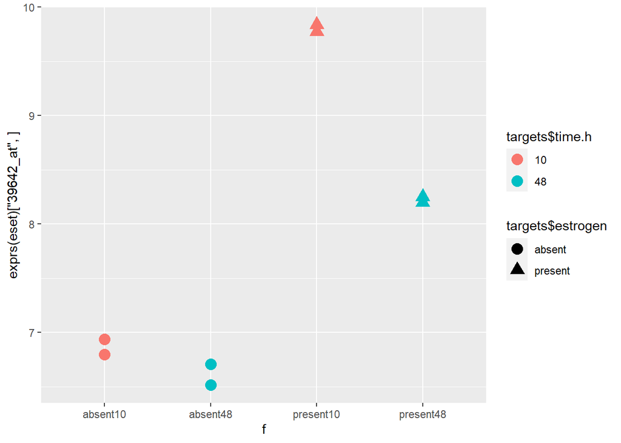

```r
qplot(x=f, y=exprs(eset)["39642_at",],) +
  geom_point(aes(shape=targets$estrogen,
                 colour=targets$time.h), size=4)
```

## Question 6

chose 910_at because it was listed in both toptables

```r
which(rownames(exprs(eset))=="910_at")
```

```
[1] 12472
```

```r
#12472
```

*logFc*

```r
mean_10_low = apply(exprs(eset)[,1:2],1,mean)
mean_10_high = apply(exprs(eset)[,3:4],1,mean)
mean_48_low = apply(exprs(eset)[,5:6],1,mean)
mean_48_high = apply(exprs(eset)[,7:8],1,mean)

mean_10_high[12472]-mean_10_low[12472] #10h
```

```
  910_at
3.113733
```

```r
#3.113733
mean_48_high[12472]-mean_48_low[12472] #48h
```

```
  910_at
3.855061
```

```r
#3.855061
```

*average expression* > is the average normalized expression value of all samples

```r
mean(exprs(eset)[12472,])
```

```
[1] 9.660238
```